# TP7 - Annal

Simon Desdevises

2025-10-06

## Lecture des données

| Contour | Depth | pH | N | Dens | P | Ca | Mg | K | Na | Conduc |
| --- | --- | --- | --- | --- | --- | --- | --- | --- | --- | --- |
| Top | 0-10 | 5.40 | 0.188 | 0.92 | 215 | 16.35 | 7.65 | 0.72 | 1.14 | 1.09 |
| Top | 0-10 | 5.65 | 0.165 | 1.04 | 208 | 12.25 | 5.15 | 0.71 | 0.94 | 1.35 |
| Top | 0-10 | 5.14 | 0.260 | 0.95 | 300 | 13.02 | 5.68 | 0.68 | 0.60 | 1.41 |
| Top | 0-10 | 5.14 | 0.169 | 1.10 | 248 | 11.92 | 7.88 | 1.09 | 1.01 | 1.64 |
| Top | 10-30 | 5.14 | 0.164 | 1.12 | 174 | 14.17 | 8.12 | 0.70 | 2.17 | 1.85 |
| Top | 10-30 | 5.10 | 0.094 | 1.22 | 129 | 8.55 | 6.92 | 0.81 | 2.67 | 3.18 |

Les données représentent différentes caractéristiques sur les sols.  
Il y a 11 variables avec parmis elle 2 qualitatives :

- `Contour`: Représentant l’endroit du prélèvement.
- `Depth` : Représentant une classe vis à vis de la profondeur du prélèvement.

Toutes les autres sont quantitative.

On retrouve :

- `pH`: ph du sol
- `N`: azote total en %
- `Dens`: densité apparente en g/cm3
- `P`: phosphore total en ppm
- `Ca`: calcium en meq/100 g.
- `Mg`: magnésium en meq/100 g
- `K`: potassium en meq/100 g
- `Na`: sodium en meq/100 g
- `Conduc`: conductivité

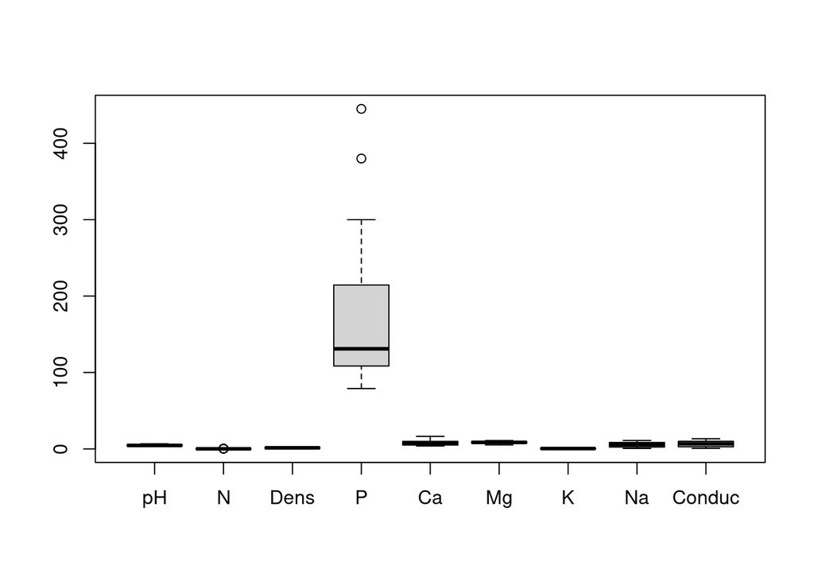

Tout d’abord on voit qu’il n’y a aucune données manquante cependant les valeurs du phospore ont un poids bien supérieur aux autres. Essayons de les normaliser

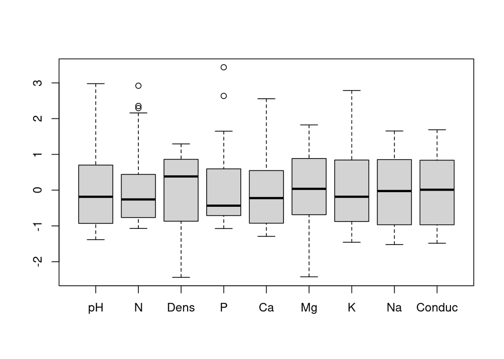

Une fois normalisé elles sont cohérente.

## Méthode utilisé

Au vu des différentes données sous allons partir sur l’utilisation de l’ACM. Pour se faire nous allons regrouper les différentes données quantitative en classe.

Voici comment sont désormais nos données :

| Contour | Depth | pH | N | Dens | P | Ca | Mg | K | Na | Conduc |
| --- | --- | --- | --- | --- | --- | --- | --- | --- | --- | --- |
| Top | 0-10 | (1,1.4] | (1,1.4] | (-2.2,-1.8] | (0.6,1] | (2.2,2.6] | (-0.6,-0.2] | (1,1.4] | (-1.4,-1] | (-1.4,-1] |
| Top | 0-10 | (1.4,1.8] | (0.6,1] | (-1.4,-1] | (0.2,0.6] | (1,1.4] | (-2.6,-2.2] | (1,1.4] | (-1.8,-1.4] | (-1.4,-1] |
| Top | 0-10 | (0.6,1] | (2.2,2.6] | (-1.8,-1.4] | (1.4,1.8] | (1.4,1.8] | (-2.2,-1.8] | (0.6,1] | (-1.8,-1.4] | (-1.4,-1] |
| Top | 0-10 | (0.6,1] | (0.6,1] | (-1,-0.6] | (1,1.4] | (1,1.4] | (-0.6,-0.2] | (2.6,3] | (-1.4,-1] | (-1.4,-1] |
| Top | 10-30 | (0.6,1] | (0.6,1] | (-1,-0.6] | (-0.2,0.2] | (1.8,2.2] | (-0.6,-0.2] | (1,1.4] | (-1.4,-1] | (-1.4,-1] |
| Top | 10-30 | (0.6,1] | (-0.2,0.2] | (-0.6,-0.2] | (-0.6,-0.2] | (-0.2,0.2] | (-1.4,-1] | (1.4,1.8] | (-1,-0.6] | (-1,-0.6] |

## Réalisation de l’ACM

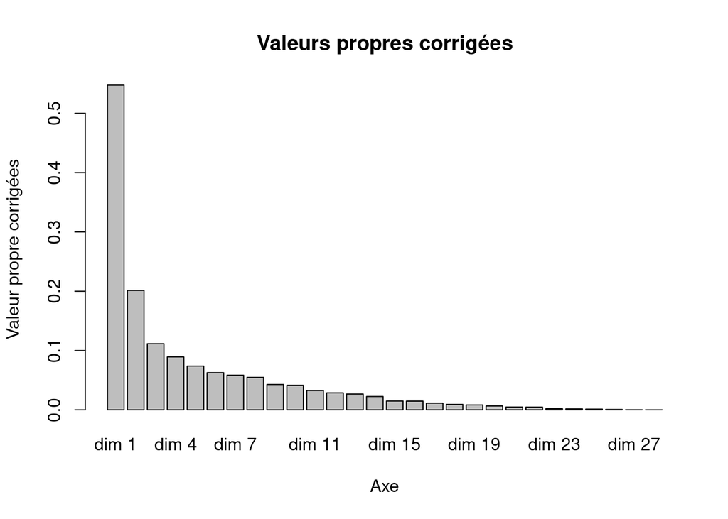

Au vu du critère du coude nous pouvons garder les 2 premières dimension.

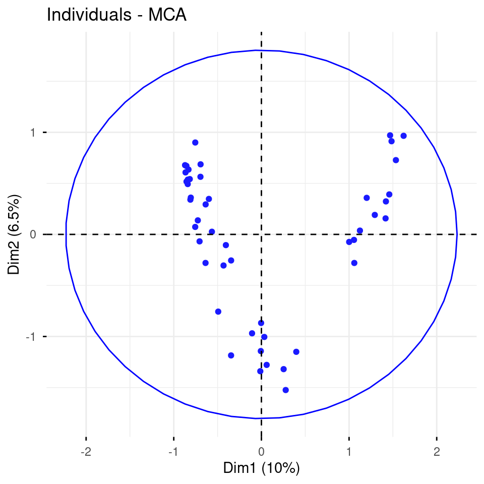

Au vu des différentes coordonnées on peut repérer 3 groupes d’individu.

## Realisation de la Classification Ascendante Hiérarchique

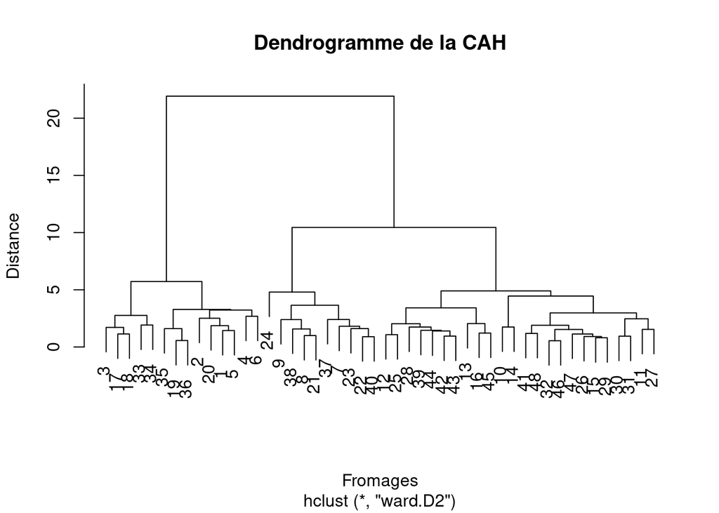

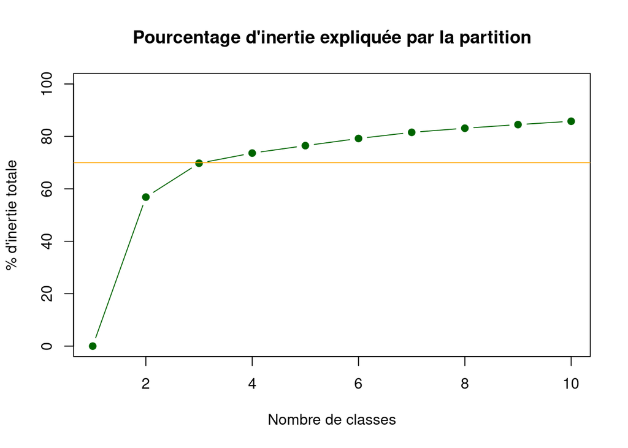

Pour expliquer 70% de l’inertie totale, on peut prendre 3 groupes. Cela est cohérents vis à vis du notre première annalyse.

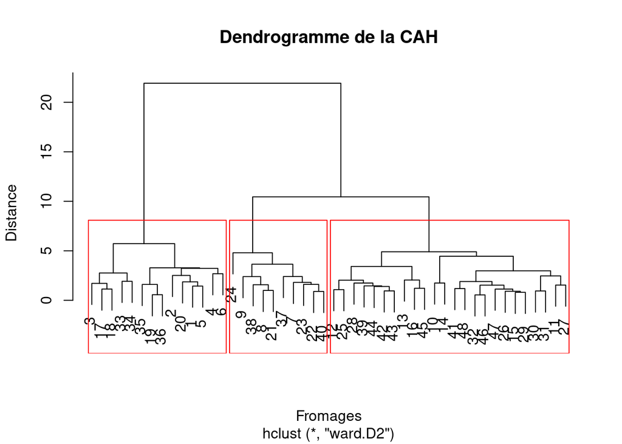